# Beach Water Quality Prediction (Sydney, NSW)

Katherine Liu

# 1 Problem Overview

## 1.1 Background, Stakeholders & Objective

Beach water quality in New South Wales (NSW) directly affects public health, beach operations, and community confidence. Early, reliable signals of deteriorating conditions help **beachgoers** make safer choices, allow **councils** to target re-sampling or temporary advisories, and support **environmental agencies** in routine monitoring.

**Objective** Using routinely collected **water-quality** measurements together with **local weather** information, we aim to **predict the daily beach status** (*Poor / Fair / Good*). The goal is not to replace expert judgement but to provide a data-driven, reproducible decision aid that balances: - Health risk (recall for *Poor* status) - Operational cost (precision for *Fair/Good* status)

## 1.2 Data Sources & Integration (Scope & Key Variables)

We use two public datasets for Greater Sydney/NSW, integrated to form modelling samples:

**1. Core Datasets** - **`water_quality.csv`** (Beachwatch official monitoring records) - Key fields: site, council, date/time, *Enterococci* counts, water temperature, conductivity, coordinates - **`weather.csv`** (local daily weather summaries) - Key fields: date, precipitation, max/min air temperature, etc.

**2. Integration Rules** - Standardise the `date` field across both datasets - Perform a **left-join on `date`** to combine records - Unit of analysis: *one record per day per site* (daily weather variables shared across same-date rows) - Multi-sample days: Aggregation rule (e.g., latest sample, daily median) specified in *Data Preparation*

## 1.3 Problem Formulation & Assumptions

We frame the task as **supervised multiclass classification**. The response variable `class` encodes daily beach status with three ordered levels (*Poor*, *Fair*, *Good*). If `class` is not provided in the raw data, it will be **derived from Enterococci thresholds** consistent with NSW guidance (details in *Data Preparation*). Predictors include routine **water-quality** measurements and **weather** summaries for the same day, optionally augmented by rolling weather windows and seasonal/context features.

**Core assumptions:**

**No leakage**: Features at day t exclude future data; all preprocessing and tuning occur within folds or chronological splits.  
**Representativeness**: Splits mirror real deployment (sites, councils, seasons); site/year-wise validation handles distribution shifts.  
**Well-posed target**:`Poor/Fair/Good` labels follow fixed policy, applied post unit-of-analysis setup.  
**Measurement consistency**: Weather data match local sampling conditions; repeated same-day samples are aggregated or modeled.

# 2 Dataset Description

## 2.1 Data Source

Final datasets **combined_data.csv** combined form (`water_quality.csv` and `weather.csv`), sourced from:  
NSW Beachwatch Water Quality Data Portal: https://www.beachwatch.nsw.gov.au/waterMonitoring/waterQualityData.

**CLICK TO EXPAND CODE**

```r
water_quality <- read.csv(here("water_quality.csv"))
weather <- read.csv(here("weather.csv"))

# Combine two datasets based on "date"
combined_data <- water_quality %>%
  left_join(weather, by = "date")

head(combined_data)
```

```
##           region                  council          swim_site       date
## 1 Western Sydney  Hawkesbury City Council      Windsor Beach 2025-04-28
## 2 Sydney Harbour     North Sydney Council Hayes Street Beach 2025-04-28
## 3 Sydney Harbour  Willoughby City Council  Northbridge Baths 2025-04-28
## 4 Sydney Harbour Northern Beaches Council    Fairlight Beach 2025-04-28
## 5 Western Sydney  Hawkesbury City Council Yarramundi Reserve 2025-04-28
## 6 Sydney Harbour Northern Beaches Council  Little Manly Cove 2025-04-28
##       time enterococci_cfu_100ml water_temperature_c conductivity_ms_cm
## 1 11:00:00                   620                  20                248
## 2 11:40:00                    64                  21              45250
## 3 10:54:00                   160                  21              48930
## 4 09:28:00                    54                  21              52700
## 5 10:35:00                   720                  18                 64
## 6 09:19:00                   230                  21              39140
##   latitude.x longitude.x max_temp_C min_temp_C precipitation_mm latitude.y
## 1  -33.60448    150.8170       20.4       14.2              1.8  -33.84886
## 2  -33.84172    151.2194       20.4       14.2              1.8  -33.84886
## 3  -33.80604    151.2228       20.4       14.2              1.8  -33.84886
## 4  -33.80073    151.2748       20.4       14.2              1.8  -33.84886
## 5  -33.60912    150.6979       20.4       14.2              1.8  -33.84886
## 6  -33.80723    151.2868       20.4       14.2              1.8  -33.84886
##   longitude.y
## 1    151.1955
## 2    151.1955
## 3    151.1955
## 4    151.1955
## 5    151.1955
## 6    151.1955
```

## 2.2 Data Description

**CLICK TO EXPAND CODE**

```r
dim(water_quality)
```

```
## [1] 123530     10
```

```r
str(water_quality)
```

```
## 'data.frame':    123530 obs. of  10 variables:
##  $ region               : chr  "Western Sydney" "Sydney Harbour" "Sydney Harbour" "Sydney Harbour" ...
##  $ council              : chr  "Hawkesbury City Council" "North Sydney Council" "Willoughby City Council" "Northern Beaches Council" ...
##  $ swim_site            : chr  "Windsor Beach" "Hayes Street Beach" "Northbridge Baths" "Fairlight Beach" ...
##  $ date                 : chr  "2025-04-28" "2025-04-28" "2025-04-28" "2025-04-28" ...
##  $ time                 : chr  "11:00:00" "11:40:00" "10:54:00" "09:28:00" ...
##  $ enterococci_cfu_100ml: int  620 64 160 54 720 230 120 280 60 100 ...
##  $ water_temperature_c  : int  20 21 21 21 18 21 21 21 22 22 ...
##  $ conductivity_ms_cm   : int  248 45250 48930 52700 64 39140 4845 50600 52900 53000 ...
##  $ latitude             : num  -33.6 -33.8 -33.8 -33.8 -33.6 ...
##  $ longitude            : num  151 151 151 151 151 ...
```

```r
dim(weather)
```

```
## [1] 12538     6
```

```r
str(weather)
```

```
## 'data.frame':    12538 obs. of  6 variables:
##  $ date            : chr  "1991-01-01" "1991-01-02" "1991-01-03" "1991-01-04" ...
##  $ max_temp_C      : num  29.3 27.5 28.2 30.8 30.4 25.5 25 22 24.3 27.3 ...
##  $ min_temp_C      : num  22.1 22.4 21.1 23.7 19.5 18.2 19.4 19.3 20.8 21.5 ...
##  $ precipitation_mm: num  2.4 0 0 0 12.2 0 0 5.2 0.7 0.4 ...
##  $ latitude        : num  -33.8 -33.8 -33.8 -33.8 -33.8 ...
##  $ longitude       : num  151 151 151 151 151 ...
```

```r
dim(combined_data)
```

```
## [1] 123530     15
```

```r
str(combined_data)
```

```
## 'data.frame':    123530 obs. of  15 variables:
##  $ region               : chr  "Western Sydney" "Sydney Harbour" "Sydney Harbour" "Sydney Harbour" ...
##  $ council              : chr  "Hawkesbury City Council" "North Sydney Council" "Willoughby City Council" "Northern Beaches Council" ...
##  $ swim_site            : chr  "Windsor Beach" "Hayes Street Beach" "Northbridge Baths" "Fairlight Beach" ...
##  $ date                 : chr  "2025-04-28" "2025-04-28" "2025-04-28" "2025-04-28" ...
##  $ time                 : chr  "11:00:00" "11:40:00" "10:54:00" "09:28:00" ...
##  $ enterococci_cfu_100ml: int  620 64 160 54 720 230 120 280 60 100 ...
##  $ water_temperature_c  : int  20 21 21 21 18 21 21 21 22 22 ...
##  $ conductivity_ms_cm   : int  248 45250 48930 52700 64 39140 4845 50600 52900 53000 ...
##  $ latitude.x           : num  -33.6 -33.8 -33.8 -33.8 -33.6 ...
##  $ longitude.x          : num  151 151 151 151 151 ...
##  $ max_temp_C           : num  20.4 20.4 20.4 20.4 20.4 20.4 20.4 20.4 20.4 20.4 ...
##  $ min_temp_C           : num  14.2 14.2 14.2 14.2 14.2 14.2 14.2 14.2 14.2 14.2 ...
##  $ precipitation_mm     : num  1.8 1.8 1.8 1.8 1.8 1.8 1.8 1.8 1.8 1.8 ...
##  $ latitude.y           : num  -33.8 -33.8 -33.8 -33.8 -33.8 ...
##  $ longitude.y          : num  151 151 151 151 151 ...
```

The **`water_quality.csv`** dataset has **123,530 samples** with **10 variables**:

**5 categorical:** `region`, `council`, `swim_site`, `date`, `time`. **5 numerical:** `enterococci_cfu_100ml`, `water_temperature_c`, `conductivity_ms_cm`, `latitude`, `longitude`.

The **`weather.csv`** dataset has **12,538 samples** with **6 variables**:

**1 categorical/temporal:** `date`. **5 numerical:** `max_temp_C`, `min_temp_C`, `precipitation_mm`, `latitude`, `longitude`.

The **`combined_data`** contains **123,530 samples** with **15 variables**, including:

**5 categorical:** `region`, `council`, `swim_site`, `date`, `time`. **10 numerical:** `enterococci_cfu_100ml`, `water_temperature_c`, `conductivity_ms_cm`, `max_temp_C`, `min_temp_C`, `precipitation_mm`, `latitude.x`, `longitude.x`, `latitude.y`, `longitude.y`.

The **`combined_data`** merges **water_quality** and **weather**, integrating categorical and continuous features to support **classification** and **predictive modeling**.

**Target Variable (class):** For modeling purposes, the numeric variable `enterococci_cfu_100ml` will be converted into a categorical water quality indicator `class` according to NSW guidelines:

**Good:** ≤ 200 CFU/100ml. **Fair:** 200 – 500 CFU/100ml. **Poor:** > 500 CFU/100ml.

## 2.3 Datasets Challenges

**2. Duplicate and Redundant Variables**: Fixed coordinates (latitude.y/longitude.y) can be removed to reduce complexity and multicollinearity.

**4. Potential Outliers**: Extreme values in enterococci_cfu_100ml, water_temperature_c, and conductivity_ms_cm may distort models and need careful handling.

**CLICK TO EXPAND CODE**

```r
summary(combined_data)
```

```
##     region            council           swim_site             date
##  Length:123530      Length:123530      Length:123530      Length:123530
##  Class :character   Class :character   Class :character   Class :character
##  Mode  :character   Mode  :character   Mode  :character   Mode  :character
##
##
##
##
##      time           enterococci_cfu_100ml water_temperature_c
##  Length:123530      Min.   :      0.0     Min.   :   0.00
##  Class :character   1st Qu.:      0.0     1st Qu.:  17.00
##  Mode  :character   Median :      4.0     Median :  20.00
##                     Mean   :    116.8     Mean   :  19.82
##                     3rd Qu.:     19.0     3rd Qu.:  22.00
##                     Max.   :1100000.0     Max.   :1040.00
##                     NA's   :307           NA's   :75039
##  conductivity_ms_cm   latitude.x      longitude.x      max_temp_C
##  Min.   :     0     Min.   :-34.07   Min.   :150.2   Min.   : 9.80
##  1st Qu.: 52600     1st Qu.:-33.91   1st Qu.:151.2   1st Qu.:18.00
##  Median : 53800     Median :-33.83   Median :151.3   Median :21.40
##  Mean   : 51560     Mean   :-33.84   Mean   :151.2   Mean   :21.43
##  3rd Qu.: 54300     3rd Qu.:-33.77   3rd Qu.:151.3   3rd Qu.:24.30
##  Max.   :710400     Max.   :-33.60   Max.   :151.3   Max.   :39.90
##  NA's   :78536
##    min_temp_C    precipitation_mm    latitude.y      longitude.y
##  Min.   : 2.20   Min.   :  0.000   Min.   :-33.85   Min.   :151.2
##  1st Qu.:11.10   1st Qu.:  0.000   1st Qu.:-33.85   1st Qu.:151.2
##  Median :14.90   Median :  0.100   Median :-33.85   Median :151.2
##  Mean   :14.61   Mean   :  1.945   Mean   :-33.85   Mean   :151.2
##  3rd Qu.:18.20   3rd Qu.:  1.300   3rd Qu.:-33.85   3rd Qu.:151.2
##  Max.   :26.40   Max.   :101.100   Max.   :-33.85   Max.   :151.2
##
```

# 3 Exploratory Data Analysis

## 3.1 Missing Values

**CLICK TO EXPAND CODE**

```r
#Calculate missing rate for each variable
miss_df <- sapply(combined_data, function(x) mean(is.na(x))) %>%
  tibble::enframe(name = "variable", value = "missing_rate") %>%
  arrange(desc(missing_rate))

miss_df
```

```
## # A tibble: 15 × 2
##    variable              missing_rate
##    <chr>                        <dbl>
##  1 conductivity_ms_cm         0.636
##  2 water_temperature_c        0.607
##  3 time                       0.0906
##  4 enterococci_cfu_100ml      0.00249
##  5 region                     0
##  6 council                    0
##  7 swim_site                  0
##  8 date                       0
##  9 latitude.x                 0
## 10 longitude.x                0
## 11 max_temp_C                 0
## 12 min_temp_C                 0
## 13 precipitation_mm           0
## 14 latitude.y                 0
## 15 longitude.y                0
```

## 3.2 Distribution of Target Variables

The target variable enterococci_cfu_100ml shows a highly right-skewed distribution with several extreme outliers. To improve interpretability and support subsequent analysis, a log transformation was applied.

**CLICK TO EXPAND CODE**

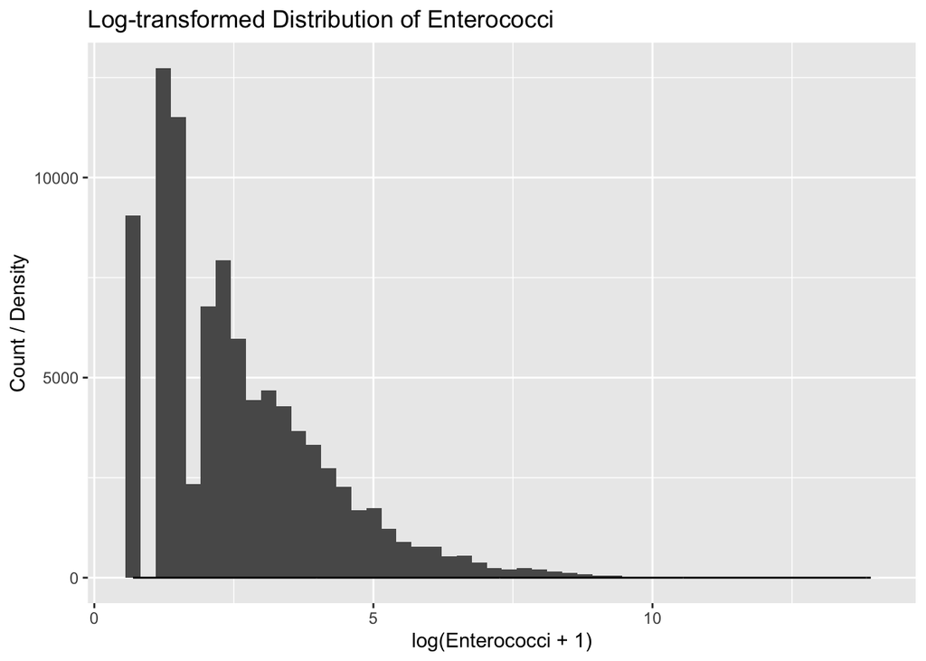

```r
combined_data <- combined_data %>%
  mutate(log_enterococci = ifelse(enterococci_cfu_100ml > 0,
                                  log1p(enterococci_cfu_100ml), NA))

ggplot(combined_data, aes(x = log_enterococci)) +
  geom_histogram(bins = 50, na.rm = TRUE) +   #silently drop NA within geoms
  geom_density(adjust = 1, na.rm = TRUE) +
  labs(title = "Log-transformed Distribution of Enterococci",
       x = "log(Enterococci + 1)",
       y = "Count / Density")
```

The log transformation effectively reduces the strong skewness in enterococci_cfu_100ml, yielding a more balanced distribution that is easier to interpret and better suited for statistical modeling and classification.

## 3.3 Distribution of binned target variable

**CLICK TO EXPAND CODE**

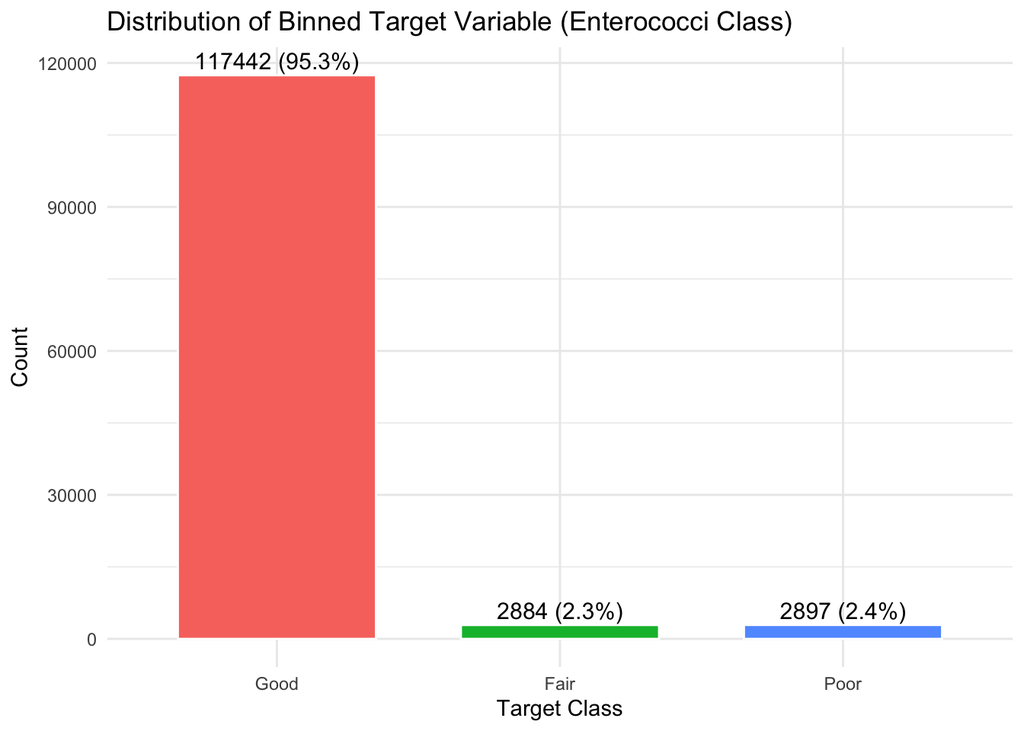

```r
combined_data <- combined_data %>%
  mutate(
    # build class label
    class = case_when(
      enterococci_cfu_100ml <= 200 ~ "Good",
      enterococci_cfu_100ml >= 201 & enterococci_cfu_100ml <= 500 ~ "Fair",
      enterococci_cfu_100ml > 500 ~ "Poor",
    ),
    class = factor(class, levels = c("Good","Fair","Poor"))
  )
class_dist <- combined_data %>%
  filter(!is.na(class)) %>%
  count(class, name = "n") %>%
  mutate(pct = n / sum(n))

ggplot(class_dist, aes(x = class, y = n, fill = class)) +
  geom_col(width = 0.7, color = "white") +
  geom_text(
    aes(label = paste0(n, " (", scales::percent(pct, accuracy = 0.1), ")")),
    vjust = -0.4, size = 4
  ) +
  labs(title = "Distribution of Binned Target Variable (Enterococci Class)",
       x = "Target Class", y = "Count") +
  theme_minimal() +
  theme(legend.position = "none")
```

The binned target variable is highly imbalanced. The Good class accounts for 95.3% of observations, while Fair and Poor comprise only 2.3% and 2.4%.

## 3.4 Relationship between Enterococci and Water Temperature

Enterococci–environment relationships were visualized: scatterplots reveal temperature associations, and log-scaling reduces skewness for clearer interpretation.

**CLICK TO EXPAND CODE**

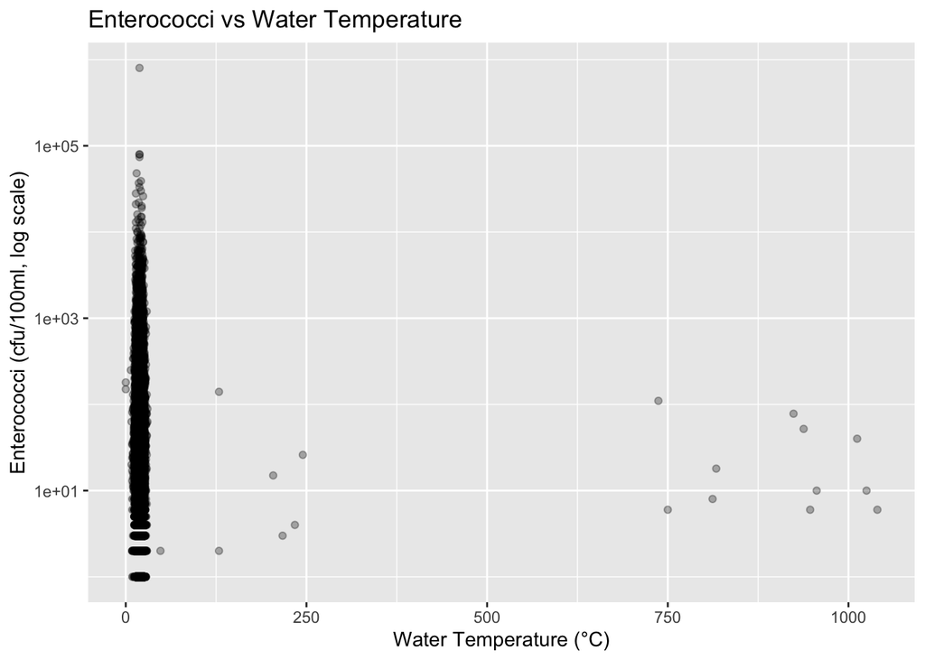

```r
#Scatterplot: enterococci vs water temperature
ggplot(
  combined_data %>%
    filter(enterococci_cfu_100ml > 0,
           is.finite(water_temperature_c)),
  aes(x = water_temperature_c, y = enterococci_cfu_100ml)
) +
  geom_point(alpha = 0.3) +
  scale_y_log10() +
  labs(
    title = "Enterococci vs Water Temperature",
    x = "Water Temperature (°C)",
    y = "Enterococci (cfu/100ml, log scale)"
  )
```

# 4 Feature Engineering

## 4.1 Data Cleaning

**CLICK TO EXPAND CODE**

```r
combined_data <- combined_data |>
  dplyr::select(-latitude.y, -longitude.y)
```

**Remove Redundant Variables**: `latitude.y`, `longitude.y` (weather station coordinates, duplicated).

**CLICK TO EXPAND CODE**

```r
# check missing value
colSums(is.na(combined_data))
```

```
##                region               council             swim_site
##                     0                     0                     0
##                  date                  time enterococci_cfu_100ml
##                     0                 11192                   307
##   water_temperature_c    conductivity_ms_cm            latitude.x
##                 75039                 78536                     0
##           longitude.x            max_temp_C            min_temp_C
##                     0                     0                     0
##      precipitation_mm       log_enterococci                 class
##                     0                 31795                   307
```

```r
# Remove rows where 'enterococci_cfu_100ml' is NA
combined_data <- combined_data %>% filter(!is.na(enterococci_cfu_100ml))

# Remove rows where 'time' is NA
combined_data <- combined_data %>% filter(!is.na(time))
```

**Remove rows with missing value**: in `enterococci_cfu_100ml`, `time`.

**CLICK TO EXPAND CODE**

```r
combined_data <- combined_data %>% filter(precipitation_mm >= 0)
combined_data <- combined_data %>% filter(water_temperature_c >= 0)
combined_data <- combined_data %>% filter(conductivity_ms_cm >= 0)
```

**Remove Negative Outliers**: `precipitation_mm`, `water_temperature_c`, `conductivity_ms_cm` **< 0**. (Only data line within physical laws).

**CLICK TO EXPAND CODE**

```r
# Month means across all years (fallback)
month_median_all_years <- combined_data %>%
  mutate(month = lubridate::month(date)) %>%
  group_by(month) %>%
  summarise(
    wt_month_median_all   = median(water_temperature_c, na.rm = TRUE),
    cond_month_median_all = median(conductivity_ms_cm,  na.rm = TRUE),
    .groups = "drop"
  )

# Year-month means
ym_median <- combined_data %>%
  mutate(year = lubridate::year(date),
         month = lubridate::month(date)) %>%
  group_by(year, month) %>%
  summarise(
    wt_ym_median = median(water_temperature_c, na.rm = TRUE),
    cond_ym_median = median(conductivity_ms_cm,  na.rm = TRUE),
    .groups = "drop"
  )

# prefer year-month mean, else fallback to all-years same-month mean
combined_data <- combined_data %>%
  mutate(year = lubridate::year(date),
         month = lubridate::month(date)) %>%
  left_join(ym_median, by = c("year","month")) %>%
  left_join(month_median_all_years, by = "month") %>%
  mutate(
    water_temperature_c = ifelse(
      is.na(water_temperature_c),
      dplyr::coalesce(wt_ym_median, wt_month_median_all),
      water_temperature_c
    ),
    conductivity_ms_cm = ifelse(
      is.na(conductivity_ms_cm),
      dplyr::coalesce(cond_ym_median, cond_month_median_all),
      conductivity_ms_cm
    )
  ) %>%
  select(-wt_ym_median, -cond_ym_median, -wt_month_median_all, -cond_month_median_all, -date)
colSums(is.na(combined_data))
```

```
##                region               council             swim_site
##                     0                     0                     0
##                  time enterococci_cfu_100ml   water_temperature_c
##                     0                     0                     0
##    conductivity_ms_cm            latitude.x           longitude.x
##                     0                     0                     0
##            max_temp_C            min_temp_C      precipitation_mm
##                     0                     0                     0
##       log_enterococci                 class                  year
##                 10711                     0                     0
##                 month
##                     0
```

**Missing Value Imputation**: `water_temperature_c` and `conductivity_ms_cm` missing value – medians imputation.

**CLICK TO EXPAND CODE**

```r
cap <- function(x, lower_q = 0.01, upper_q = 0.99) {
  qnt <- quantile(x, probs = c(lower_q, upper_q), na.rm = TRUE)
  x[x < qnt[1]] <- qnt[1]
  x[x > qnt[2]] <- qnt[2]
  return(x)
}

combined_data$enterococci_cfu_100ml <- cap(combined_data$enterococci_cfu_100ml)
combined_data$water_temperature_c <- cap(combined_data$water_temperature_c)
combined_data$conductivity_ms_cm  <- cap(combined_data$conductivity_ms_cm)
```

**Outlier Handling**: `enterococci_cfu_100ml`, `water_temperature_c`, `conductivity_ms_cm` – `1-99th` percentiles bounds, control extremes.

**CLICK TO EXPAND CODE**

```r
summary(combined_data)
```

```
##     region            council           swim_site             time
##  Length:40188       Length:40188       Length:40188       Length:40188
##  Class :character   Class :character   Class :character   Class :character
##  Mode  :character   Mode  :character   Mode  :character   Mode  :character
##
##
##
##
##  enterococci_cfu_100ml water_temperature_c conductivity_ms_cm   latitude.x
##  Min.   :  0.00        Min.   :14.00       Min.   :   73      Min.   :-34.07
##  1st Qu.:  0.00        1st Qu.:17.00       1st Qu.:52600      1st Qu.:-33.92
##  Median :  3.00        Median :20.00       Median :53800      Median :-33.84
##  Mean   : 30.39        Mean   :19.68       Mean   :51427      Mean   :-33.84
##  3rd Qu.: 14.00        3rd Qu.:22.00       3rd Qu.:54300      3rd Qu.:-33.75
##  Max.   :811.30        Max.   :25.00       Max.   :55300      Max.   :-33.60
##
##   longitude.x      max_temp_C      min_temp_C    precipitation_mm
##  Min.   :150.2   Min.   : 9.80   Min.   : 2.20   Min.   : 0.000
##  1st Qu.:151.2   1st Qu.:18.90   1st Qu.:11.10   1st Qu.: 0.000
##  Median :151.3   Median :22.20   Median :15.00   Median : 0.200
##  Mean   :151.2   Mean   :22.32   Mean   :14.54   Mean   : 2.482
##  3rd Qu.:151.3   3rd Qu.:25.10   3rd Qu.:18.30   3rd Qu.: 1.900
##  Max.   :151.3   Max.   :39.90   Max.   :26.40   Max.   :67.600
##
##  log_enterococci   class            year          month
##  Min.   : 0.693   Good:38846   Min.   :2008   Min.   : 1.000
##  1st Qu.: 1.099   Fair:  695   1st Qu.:2016   1st Qu.: 3.000
##  Median : 1.946   Poor:  647   Median :2019   Median : 6.000
##  Mean   : 2.342                Mean   :2019   Mean   : 6.476
##  3rd Qu.: 3.135                3rd Qu.:2022   3rd Qu.:10.000
##  Max.   :10.571                Max.   :2025   Max.   :12.000
##  NA's   :10711
```

## 4.2 Feature Scaling and Construction

**CLICK TO EXPAND CODE**

```r
num_vars <- c("water_temperature_c", "precipitation_mm", "conductivity_ms_cm")
combined_data[num_vars] <- scale(combined_data[num_vars])
```

**Scale Key Numerical Features**: `water_temperature_c`: 14–25, `precipitation_mm`: 0–67.6, `conductivity_ms_cm`: 73–55,300, different scales – Standardize (z-score).

**CLICK TO EXPAND CODE**

```r
combined_data <- combined_data %>%
  mutate(
    # build class label
    class = case_when(
      enterococci_cfu_100ml <= 200 ~ "Good",
      enterococci_cfu_100ml >= 201 & enterococci_cfu_100ml <= 500 ~ "Fair",
      enterococci_cfu_100ml > 500 ~ "Poor",
    ),
    class = factor(class, levels = c("Good","Fair","Poor"))
  )
```

**Build 3-class labels**: class: `Good`<=200, 200<`Fair`<=500, `Poor`>500 from `enterococci_cfu_100ml`.

**CLICK TO EXPAND CODE**

```r
summary(combined_data)
```

```
##     region            council           swim_site             time
##  Length:40188       Length:40188       Length:40188       Length:40188
##  Class :character   Class :character   Class :character   Class :character
##  Mode  :character   Mode  :character   Mode  :character   Mode  :character
##
##
##
##
##  enterococci_cfu_100ml water_temperature_c conductivity_ms_cm   latitude.x
##  Min.   :  0.00        Min.   :-2.1239     Min.   :-5.9590    Min.   :-34.07
##  1st Qu.:  0.00        1st Qu.:-1.0012     1st Qu.: 0.1361    1st Qu.:-33.92
##  Median :  3.00        Median : 0.1216     Median : 0.2754    Median :-33.84
##  Mean   : 30.39        Mean   : 0.0000     Mean   : 0.0000    Mean   :-33.84
##  3rd Qu.: 14.00        3rd Qu.: 0.8702     3rd Qu.: 0.3334    3rd Qu.:-33.75
##  Max.   :811.30        Max.   : 1.9929     Max.   : 0.4494    Max.   :-33.60
##
##   longitude.x      max_temp_C      min_temp_C    precipitation_mm
##  Min.   :150.2   Min.   : 9.80   Min.   : 2.20   Min.   :-0.40261
##  1st Qu.:151.2   1st Qu.:18.90   1st Qu.:11.10   1st Qu.:-0.40261
##  Median :151.3   Median :22.20   Median :15.00   Median :-0.37016
##  Mean   :151.2   Mean   :22.32   Mean   :14.54   Mean   : 0.00000
##  3rd Qu.:151.3   3rd Qu.:25.10   3rd Qu.:18.30   3rd Qu.:-0.09438
##  Max.   :151.3   Max.   :39.90   Max.   :26.40   Max.   :10.56363
##
##  log_enterococci   class            year          month
##  Min.   : 0.693   Good:38846   Min.   :2008   Min.   : 1.000
##  1st Qu.: 1.099   Fair:  695   1st Qu.:2016   1st Qu.: 3.000
##  Median : 1.946   Poor:  647   Median :2019   Median : 6.000
##  Mean   : 2.342                Mean   :2019   Mean   : 6.476
##  3rd Qu.: 3.135                3rd Qu.:2022   3rd Qu.:10.000
##  Max.   :10.571                Max.   :2025   Max.   :12.000
##  NA's   :10711
```

## 4.3 Feature Transformation and Interaction

Improve minority class `Fair` and `Poor` model performance.

**CLICK TO EXPAND CODE**

```r
# 1. Log transform enterococci and conductivity
combined_data <- combined_data %>%
  mutate(log_enterococci = log1p(enterococci_cfu_100ml))           # log transform enterococci


# 2. Yeo-Johnson transform for precipitation_mm
preProc <- preProcess(combined_data %>% select(precipitation_mm), method = "YeoJohnson")
combined_data$yeojohnson_precip <- predict(preProc, combined_data %>% select(precipitation_mm))$precipitation_mm
# Extract transformed precipitation

# 3. Create interaction features and derived features
combined_data <- combined_data %>%
  mutate(
    temp_ec_interact = water_temperature_c * log_enterococci,
    temp_diff = max_temp_C - min_temp_C
  )
```

**Non-linear transformation of key variables**: `enterococci_cfu_100ml` -> `log_enterococci`, `precipitation_mm` -> `yeojohnson_precip`. **Interaction and difference features**: `temp_ec_interact`=`water_temperature_c*log_enterococci`, `temp_diff=`max_temp_C-min_temp_C`.

**CLICK TO EXPAND CODE**

```r
combined_data <- combined_data %>%
  mutate(
    season = case_when(
      month %in% c(12,1,2) ~ "Summer",
      month %in% c(3,4,5)  ~ "Autumn",
      month %in% c(6,7,8)  ~ "Winter",
      TRUE ~ "Spring"
    ),
    season = factor(season, levels = c("Summer", "Autumn", "Winter", "Spring"))
  )
```

**Time and seasonal features**: `month` -> `season`.

**CLICK TO EXPAND CODE**

```r
summary(combined_data)
```

```
##     region            council           swim_site             time
##  Length:40188       Length:40188       Length:40188       Length:40188
##  Class :character   Class :character   Class :character   Class :character
##  Mode  :character   Mode  :character   Mode  :character   Mode  :character
##
##
##
##  enterococci_cfu_100ml water_temperature_c conductivity_ms_cm   latitude.x
##  Min.   :  0.00        Min.   :-2.1239     Min.   :-5.9590    Min.   :-34.07
##  1st Qu.:  0.00        1st Qu.:-1.0012     1st Qu.: 0.1361    1st Qu.:-33.92
##  Median :  3.00        Median : 0.1216     Median : 0.2754    Median :-33.84
##  Mean   : 30.39        Mean   : 0.0000     Mean   : 0.0000    Mean   :-33.84
##  3rd Qu.: 14.00        3rd Qu.: 0.8702     3rd Qu.: 0.3334    3rd Qu.:-33.75
##  Max.   :811.30        Max.   : 1.9929     Max.   : 0.4494    Max.   :-33.60
##   longitude.x      max_temp_C      min_temp_C    precipitation_mm
##  Min.   :150.2   Min.   : 9.80   Min.   : 2.20   Min.   :-0.40261
##  1st Qu.:151.2   1st Qu.:18.90   1st Qu.:11.10   1st Qu.:-0.40261
##  Median :151.3   Median :22.20   Median :15.00   Median :-0.37016
##  Mean   :151.2   Mean   :22.32   Mean   :14.54   Mean   : 0.00000
##  3rd Qu.:151.3   3rd Qu.:25.10   3rd Qu.:18.30   3rd Qu.:-0.09438
##  Max.   :151.3   Max.   :39.90   Max.   :26.40   Max.   :10.56363
##  log_enterococci  class            year          month        yeojohnson_precip
##  Min.   :0.000   Good:38846   Min.   :2008   Min.   : 1.000   Min.   :-0.7766
##  1st Qu.:0.000   Fair:  695   1st Qu.:2016   1st Qu.: 3.000   1st Qu.:-0.7766
##  Median :1.386   Poor:  647   Median :2019   Median : 6.000   Median :-0.6787
##  Mean   :1.710                Mean   :2019   Mean   : 6.476   Mean   :-0.4371
##  3rd Qu.:2.708                3rd Qu.:2022   3rd Qu.:10.000   3rd Qu.:-0.1106
##  Max.   :6.700                Max.   :2025   Max.   :12.000   Max.   : 0.4189
##  temp_ec_interact     temp_diff         season
##  Min.   :-14.2301   Min.   : 0.800   Summer:11571
##  1st Qu.: -0.5817   1st Qu.: 5.300   Autumn:10118
##  Median :  0.0000   Median : 7.500   Winter: 8055
##  Mean   :  0.2012   Mean   : 7.782   Spring:10444
##  3rd Qu.:  1.0312   3rd Qu.: 9.700
##  Max.   : 13.3525   Max.   :22.300
```

**CLICK TO EXPAND CODE**

```r
write.csv(combined_data, here("combined_data.csv"))
```

## 4.4 Split Dataset and Handle Class Imbalance

**CLICK TO EXPAND CODE**

```r
set.seed(5003)

# Split data into training (80%) and testing (20%) sets
train_index <- createDataPartition(combined_data$class, p = 0.8, list = FALSE)
train_data <- combined_data[train_index, ]
test_data <- combined_data[-train_index, ]

# Check the original class distribution in the training set
table(train_data$class)
```

```
##
##  Good  Fair  Poor
## 31077   556   518
```

**Split dataset**: **training (80%)**, **testing (20%)** before model training.

**CLICK TO EXPAND CODE**

```r
train_data_balanced <- downSample(
  x = train_data %>% select(log_enterococci, yeojohnson_precip, temp_ec_interact, temp_diff, season),
  y = train_data$class
)
train_data_balanced <- train_data_balanced %>% rename(class = Class)

# Check the balanced class distribution in the training set
table(train_data_balanced$class)
```

```
##
## Good Fair Poor
##  518  518  518
```

**Handling Class Imbalance (Downsampling within Training Set Only)**: Since the target variable `class` is extremely imbalanced, **down-sampling** was applied only to the training set to balance the classes, test set remains imbalanced, reflecting real-world performance.

**CLICK TO EXPAND CODE**

```r
# Set up parallel computing
cl <- makeCluster(parallel::detectCores() - 1)
registerDoParallel(cl)

train_control <- trainControl(
  method = "cv",                 # 10-fold cross-validation
  number = 10,
  classProbs = TRUE,             # Enable probability predictions
  summaryFunction = multiClassSummary,  # Evaluate multi-class metrics
  allowParallel = TRUE           # Enable multi-core processing
)
```

**10-Fold Cross-Validation with Parallel Training**: To optimize model training and evaluate performance robustly, CV - robust estimate of generalization, Parallel - accelerates computation.

# 5 Classification Models Used

## 5.1 Multinomial Logistic Regression

**Hyperparameter Tuning**: Across folds, cross-validated performance was uniform over different values of decay, with the best mean accuracy at the highest regularization (decay ≈ 1.0). Since variance is low across folds, the model is not very sensitive to the strength of the penalty.

**CLICK TO EXPAND CODE**

```r
grid <- expand.grid(decay = c(0, 0.001, 0.01, 0.1, 0.5, 1))

mlr_model <- train(
  class ~ .,
  data       = train_data_balanced,
  method     = "multinom",
  trControl  = train_control,
  tuneGrid   = grid,
  preProcess = c("center", "scale"),
  trace      = FALSE,
  MaxNWts    = 5000
)

pred_cls <- predict(mlr_model, newdata = test_data)
pred_prb <- predict(mlr_model, newdata = test_data, type = "prob")

confusionMatrix(pred_cls, reference = test_data$class)
```

```
## Confusion Matrix and Statistics
##
##           Reference
## Prediction Good Fair Poor
##       Good 7712    0    0
##       Fair   57  139    1
##       Poor    0    0  128
##
## Overall Statistics
##
##                Accuracy : 0.9928
##                  95% CI : (0.9907, 0.9945)
##     No Information Rate : 0.9667
##     P-Value [Acc > NIR] : < 2.2e-16
##
##                   Kappa : 0.8994
##
##  Mcnemar's Test P-Value : NA
##
## Statistics by Class:
##
##                      Class: Good Class: Fair Class: Poor
## Sensitivity               0.9927     1.00000     0.99225
## Specificity               1.0000     0.99266     1.00000
## Pos Pred Value            1.0000     0.70558     1.00000
## Neg Pred Value            0.8246     1.00000     0.99987
## Prevalence                0.9667     0.01730     0.01605
## Detection Rate            0.9596     0.01730     0.01593
## Detection Prevalence      0.9596     0.02451     0.01593
## Balanced Accuracy         0.9963     0.99633     0.99612
```

**Test Performance**: Accuracy: 0.9928 (95% CI: 0.9907–0.9945), Kappa: 0.8994 — strong overall agreement.

**Per-class metrics**: • Good: Recall 0.993, Precision 1.000, Balanced Accuracy 0.996. • Fair: Recall 1.000, Precision 0.706, Balanced Accuracy 0.996. • Poor: Recall 0.992, Precision 1.000, Balanced Accuracy 0.996.

**Interpretation**:The model reliably distinguishes all classes. Lower Fair precision reflects class imbalance; a few non-linear or interaction terms could further improve minority-class predictions.

## 5.2 Linear Discriminant Analysis (LDA)

**CLICK TO EXPAND CODE**

```r
lda_model <- train(
  class ~ .,
  data        = train_data_balanced,
  method      = "lda",
  preProcess  = c("center", "scale"),
  trControl   = train_control
)

pred_class <- predict(lda_model, newdata = test_data)
confusionMatrix(pred_class, test_data$class)
```

```
## Confusion Matrix and Statistics
##
##           Reference
## Prediction Good Fair Poor
##       Good 7007    0    0
##       Fair  762  118    3
##       Poor    0   21  126
##
## Overall Statistics
##
##                Accuracy : 0.9022
##                  95% CI : (0.8955, 0.9086)
##     No Information Rate : 0.9667
##     P-Value [Acc > NIR] : 1
##
##                   Kappa : 0.3692
##
##  Mcnemar's Test P-Value : NA
##
## Statistics by Class:
##
##                      Class: Good Class: Fair Class: Poor
## Sensitivity               0.9019     0.84892     0.97674
## Specificity               1.0000     0.90314     0.99734
## Pos Pred Value            1.0000     0.13364     0.85714
## Neg Pred Value            0.2602     0.99706     0.99962
## Prevalence                0.9667     0.01730     0.01605
## Detection Rate            0.8718     0.01468     0.01568
## Detection Prevalence      0.8718     0.10987     0.01829
## Balanced Accuracy         0.9510     0.87603     0.98704
```

```r
pred_prob <- predict(lda_model, newdata = test_data, type = "prob")
```

**Before Hyperparameter Tuning**: The model achieved Accuracy = 0.9022 (95% CI: 0.8955–0.9086) and Kappa = 0.3692, indicating weak agreement beyond chance. Accuracy was below the No Information Rate (0.9667), reflecting strong class imbalance.

**Performance by Class:** • Good: Recall = 0.902, Precision = 1.000 — strong detection, minor confusion with Fair. • Fair: Recall = 0.849, Precision = 0.134 — poor precision due to heavy misclassification. • Poor: Recall = 0.977, Precision = 0.857 — high accuracy and minimal confusion.

**Interpretation:** Before tuning, the model performs well on Good and Poor classes but struggles with Fair due to imbalance and overlapping features. Results highlight the limits of linear boundaries under skewed class distributions.

**CLICK TO EXPAND CODE**

```r
lda_model_tuned <- train(
  class ~ .,
  data        = train_data_balanced,
  method      = "lda",
  preProcess  = c("center", "scale"),
  trControl   = train_control,
  tuneGrid    = data.frame(parameter = "none"),
  prior = c(0.35, 0.35, 0.3)
)

pred_class_tuned <- predict(lda_model_tuned, newdata = test_data)
confusionMatrix(pred_class_tuned, test_data$class)
```

```
## Confusion Matrix and Statistics
##
##           Reference
## Prediction Good Fair Poor
##       Good 7007    0    0
##       Fair  762  127    6
##       Poor    0   12  123
##
## Overall Statistics
##
##                Accuracy : 0.9029
##                  95% CI : (0.8963, 0.9093)
##     No Information Rate : 0.9667
##     P-Value [Acc > NIR] : 1
##
##                   Kappa : 0.374
##
##  Mcnemar's Test P-Value : NA
##
## Statistics by Class:
##
##                      Class: Good Class: Fair Class: Poor
## Sensitivity               0.9019      0.9137     0.95349
## Specificity               1.0000      0.9028     0.99848
## Pos Pred Value            1.0000      0.1419     0.91111
## Neg Pred Value            0.2602      0.9983     0.99924
## Prevalence                0.9667      0.0173     0.01605
## Detection Rate            0.8718      0.0158     0.01530
## Detection Prevalence      0.8718      0.1114     0.01680
## Balanced Accuracy         0.9510      0.9082     0.97599
```

```r
pred_prob_tuned <- predict(lda_model_tuned, newdata = test_data, type = "prob")
```

**After Hyperparameter Tuning**: The model achieved Accuracy = 0.9029 (95% CI: 0.8963–0.9093) and Kappa = 0.374, showing slight improvement over pre-tuning performance. Accuracy remains below the NIR (0.9667), reflecting ongoing class imbalance.

**Performance by Class:** • Good: Recall = 0.902, Precision = 1.000 — stable, no false positives. • Fair: Recall = 0.914, Precision = 0.142 — improved recall and balance, better detection of Fair samples. • Poor: Recall = 0.953, Precision = 0.911 — improved precision, minor recall drop.

## 5.3 Support Vector Machine (SVM)

**Rationale**: We use an RBF-kernel SVM to capture possible non-linear boundaries. Predictors are centred/scaled. We first fit a **no-CV baseline** (fast), then a **tiny 2-fold CV** with a small grid for a quick improvement.

**CLICK TO EXPAND CODE**

```r
suppressPackageStartupMessages({
  library(readr); library(dplyr); library(tidyr); library(caret); library(kernlab); library(knitr)
})
set.seed(42)

dat <- read_csv("combined_data.csv", show_col_types = FALSE)

if (!("class" %in% names(dat))) {
  y_guess <- grep("^(class|grade|status|risk)$", names(dat), ignore.case = TRUE, value = TRUE)
  if (length(y_guess) == 0) stop("Please rename your label column to 'class' (or one of: class/grade/status/risk).")
  dat <- dplyr::rename(dat, class = !!rlang::sym(y_guess[1]))
}

dat <- dat %>%
  mutate(
    across(where(is.character), as.factor),
    across(where(is.logical),  as.factor),
    across(where(function(x) inherits(x, "Date")), as.numeric),
    across(where(function(x) inherits(x, "POSIXct")), as.numeric)
  )

good_cols <- names(dat)[vapply(dat, function(x) is.numeric(x) || is.factor(x), logical(1))]
keep_all  <- unique(c("class", setdiff(good_cols, "class")))
dat <- dat %>% select(all_of(keep_all))

dat <- dat %>%
  filter(!is.na(class)) %>%
  mutate(class = factor(as.character(class), levels = c("Poor","Fair","Good"), ordered = TRUE)) %>%
  tidyr::drop_na()
stopifnot("class" %in% names(dat))

idx   <- createDataPartition(dat$class, p = 0.8, list = FALSE)
train <- dat[idx, , drop = FALSE]
test  <- dat[-idx, , drop = FALSE]

nz <- nearZeroVar(train %>% select(-class))
if (length(nz) > 0) {
  drop_names <- names(train %>% select(-class))[nz]
  train <- train %>% select(-all_of(drop_names))
  test  <- test  %>% select(all_of(names(train)))
}

ctrl_none <- trainControl(method = "none")
num_mat <- train %>% select(where(is.numeric)) %>% as.matrix()
if (nrow(num_mat) > 1500) num_mat <- num_mat[sample.int(nrow(num_mat), 1500), , drop = FALSE]
sg <- tryCatch(as.numeric(kernlab::sigest(num_mat, frac = 1)[2]), error = function(e) NA)
if (is.na(sg)) sg <- 0.1

svm_base <- train(
  class ~ ., data = train,
  method = "svmRadial",
  preProcess = c("center","scale"),
  trControl = ctrl_none,
  tuneGrid  = data.frame(sigma = sg, C = 1),
  metric    = "Accuracy"
)

pred0 <- predict(svm_base, newdata = test)
cm0   <- confusionMatrix(pred0, test$class)

cat("**Baseline (no CV)**\n")
```

```
## **Baseline (no CV)**
```

```r
kable(t(round(cm0$overall[c("Accuracy","Kappa")], 4)), col.names = c("Accuracy","Kappa"))
```

| Accuracy | Kappa |
| --- | --- |
| 0.9851 | 0.7169 |

```r
kable(round(as.data.frame(cm0$byClass)[, c("Precision","Recall","F1")], 4))
```

|  | Precision | Recall | F1 |
| --- | --- | --- | --- |
| Class: Poor | 0.9304 | 0.8295 | 0.8770 |
| Class: Fair | 0.8776 | 0.3094 | 0.4574 |
| Class: Good | 0.9865 | 0.9997 | 0.9931 |

```r
ctrl_fast <- trainControl(method = "cv", number = 2, summaryFunction = defaultSummary)
grid <- expand.grid(sigma = sg * c(0.8, 1, 2), C = c(1, 5))

svm_tune <- train(
  class ~ ., data = train,
  method = "svmRadial",
  preProcess = c("center","scale"),
  trControl = ctrl_fast,
  tuneGrid  = grid,
  metric    = "Accuracy"
)

pred <- predict(svm_tune, newdata = test)
cm   <- confusionMatrix(pred, test$class)

cat("\n**Tuned (2-fold CV, small grid)**\n")
```

```
##
## **Tuned (2-fold CV, small grid)**
```

```r
kable(svm_tune$bestTune, row.names = FALSE)
```

| sigma | C |
| --- | --- |
| 0.0342668 | 5 |

```r
kable(data.frame(CV_Best_Accuracy = round(max(svm_tune$results$Accuracy, na.rm = TRUE), 4)))
```

| CV_Best_Accuracy |
| --- |
| 0.9855 |

```r
kable(t(round(cm$overall[c("Accuracy","Kappa")], 4)), col.names = c("Accuracy","Kappa"))
```

| Accuracy | Kappa |
| --- | --- |
| 0.9909 | 0.85 |

```r
kable(round(as.data.frame(cm$byClass)[, c("Precision","Recall","F1")], 4))
```

|  | Precision | Recall | F1 |
| --- | --- | --- | --- |
| Class: Poor | 0.9350 | 0.8915 | 0.9127 |
| Class: Fair | 0.8411 | 0.6475 | 0.7317 |
| Class: Good | 0.9939 | 0.9987 | 0.9963 |

**Per-class metrics**: • Good: Precision 0.994, Recall 0.999, F1 0.996. • Poor: Precision 0.935, Recall 0.892, F1 0.913. • Fair: Precision 0.841, Recall 0.648, F1 0.732.

The model excels on Good, maintains high Poor recall (~0.89), but Fair recall is lower (~0.65), reflecting difficulty in predicting the middle class.

**Actionable next steps (to improve Fair performance without increasing false alarms):**

**Thresholding / class-specific operating points:** Tune decision thresholds using per-class PR curves to improve Fair recall at a controlled precision loss. **Mild rebalancing or costs:** Apply in-fold up-sampling or class weights (higher weight on Fair) within `trainControl` to trade a small drop in overall accuracy for better Fair sensitivity. **Feature diagnostics:** Use permutation importance and partial-dependence on weather/season features to identify where Fair–Good boundaries blur; this can guide targeted feature engineering.

## 5.4 K-nearest Neighbors (KNN)

**CLICK TO EXPAND CODE**

```r
knn_model <- train(
  class ~ .,
  data        = train_data_balanced,
  method      = "knn",
  preProcess  = c("center", "scale"),
  tuneGrid    = data.frame(k = 5),
  trControl   = train_control
)

pred_class <- predict(knn_model, newdata = test_data)
confusionMatrix(pred_class, test_data$class)
```

```
## Confusion Matrix and Statistics
##
##           Reference
## Prediction Good Fair Poor
##       Good 7319    0    0
##       Fair  435  112   24
##       Poor   15   27  105
##
## Overall Statistics
##
##                Accuracy : 0.9377
##                  95% CI : (0.9322, 0.9429)
##     No Information Rate : 0.9667
##     P-Value [Acc > NIR] : 1
##
##                   Kappa : 0.4725
##
##  Mcnemar's Test P-Value : <2e-16
##
## Statistics by Class:
##
##                      Class: Good Class: Fair Class: Poor
## Sensitivity               0.9421     0.80576     0.81395
## Specificity               1.0000     0.94188     0.99469
## Pos Pred Value            1.0000     0.19615     0.71429
## Neg Pred Value            0.3733     0.99638     0.99696
## Prevalence                0.9667     0.01730     0.01605
## Detection Rate            0.9107     0.01394     0.01306
## Detection Prevalence      0.9107     0.07105     0.01829
## Balanced Accuracy         0.9710     0.87382     0.90432
```

```r
pred_prob <- predict(knn_model, newdata = test_data, type = "prob")
```

**K-nearest Neighbors (KNN) – Baseline Performance (Before Tuning)** Accuracy: 0.9377 (95% CI: 0.9322–0.9429). Kappa: 0.4725 -> moderate agreement.

Per-class: • Good: Recall 0.942, Precision 1.000 -> near-perfect classification. • Fair: Recall 0.806, Precision 0.196 -> frequent false positives. • Poor: Recall 0.814, Precision 0.714 -> balanced but some confusion with Fair.

**Interpretation:** KNN performs excellently on the majority Good class but struggles with Fair due to high class overlap. Poor is reasonably well detected, though minor misclassification persists.

**CLICK TO EXPAND CODE**

```r
knn_grid <- expand.grid(
  k = c(3,5,7,9,11,13,15,21,31)
)

knn_tune <- train(
  class ~ .,
  data       = train_data_balanced,
  method     = "knn",
  preProcess = c("center","scale"),
  tuneGrid   = knn_grid,
  trControl  = train_control,
  metric     = "Mean_F1"
)

knn_tune$bestTune
```

```
##   k
## 2 5
```

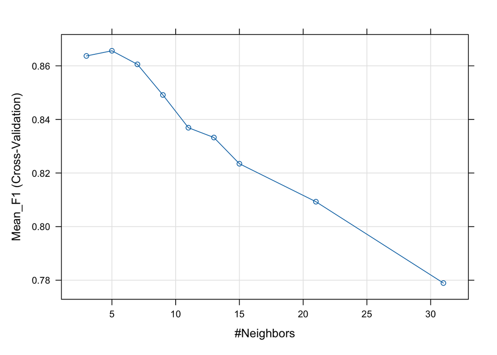

```r
plot(knn_tune)
```

```r
pred_class <- predict(knn_tune, newdata = test_data)
confusionMatrix(pred_class, test_data$class)
```

```
## Confusion Matrix and Statistics
##
##           Reference
## Prediction Good Fair Poor
##       Good 7321    0    0
##       Fair  434  113   24
##       Poor   14   26  105
##
## Overall Statistics
##
##                Accuracy : 0.938
##                  95% CI : (0.9325, 0.9432)
##     No Information Rate : 0.9667
##     P-Value [Acc > NIR] : 1
##
##                   Kappa : 0.4746
##
##  Mcnemar's Test P-Value : <2e-16
##
## Statistics by Class:
##
##                      Class: Good Class: Fair Class: Poor
## Sensitivity               0.9423     0.81295     0.81395
## Specificity               1.0000     0.94201     0.99494
## Pos Pred Value            1.0000     0.19790     0.72414
## Neg Pred Value            0.3743     0.99652     0.99696
## Prevalence                0.9667     0.01730     0.01605
## Detection Rate            0.9109     0.01406     0.01306
## Detection Prevalence      0.9109     0.07105     0.01804
## Balanced Accuracy         0.9712     0.87748     0.90445
```

```r
pred_prob <- predict(knn_tune, newdata = test_data, type = "prob")
head(pred_prob)
```

```
##   Good Fair Poor
## 1    0  1.0  0.0
## 2    0  0.8  0.2
## 3    1  0.0  0.0
## 4    1  0.0  0.0
## 5    1  0.0  0.0
## 6    1  0.0  0.0
```

**KNN – After Hyperparameter Tuning** Optimal k = 5 -> best balance between bias and variance. Accuracy: 0.9380. Kappa: 0.4746 -> moderate agreement.

Per-class: • Fair: Recall 0.813, Precision 0.198 -> strong recall, low precision. • Poor: Recall 0.814, Precision 0.724 -> balanced, slightly improved.

## 5.5 Naive Bayes

**CLICK TO EXPAND CODE**

```r
nb_model <- train(
  class ~ .,
  data = train_data_balanced,
  method = "naive_bayes",
  trControl = train_control
)

# Evaluation on the **original imbalanced test set** to assess the model’s real-world performance.
pred_class <- predict(nb_model, newdata = test_data)
confusionMatrix(pred_class, test_data$class)
```

```
## Confusion Matrix and Statistics
##
##           Reference
## Prediction Good Fair Poor
##       Good 7586    0    0
##       Fair   75  139    1
##       Poor  108    0  128
##
## Overall Statistics
##
##                Accuracy : 0.9771
##                  95% CI : (0.9736, 0.9803)
##     No Information Rate : 0.9667
##     P-Value [Acc > NIR] : 2.138e-08
##
##                   Kappa : 0.7358
##
##  Mcnemar's Test P-Value : < 2.2e-16
##
## Statistics by Class:
##
##                      Class: Good Class: Fair Class: Poor
## Sensitivity               0.9764     1.00000     0.99225
## Specificity               1.0000     0.99038     0.98634
## Pos Pred Value            1.0000     0.64651     0.54237
## Neg Pred Value            0.5942     1.00000     0.99987
## Prevalence                0.9667     0.01730     0.01605
## Detection Rate            0.9439     0.01730     0.01593
## Detection Prevalence      0.9439     0.02675     0.02936
## Balanced Accuracy         0.9882     0.99519     0.98930
```

**Naive Bayes – Before Hyperparameter Tuning** Accuracy: 0.9771. Kappa: 0.7358 -> strong overall agreement but class imbalance persists.

Per-class: • Good: PPV 1.000, Sensitivity 0.976 -> near-perfect performance. • Fair: PPV 0.647 -> moderate precision. • Poor: PPV 0.542 -> frequent confusion with Good.

**Summary:** Excellent accuracy driven by the dominant Good class, but Fair and Poor remain harder to distinguish, suggesting a need for tuning or resampling to improve minority detection.

**CLICK TO EXPAND CODE**

```r
# Define tuning grid for Naive Bayes
nb_grid <- expand.grid(
  usekernel = c(TRUE, FALSE),
  laplace = c(0, 1, 5, 10),
  adjust = c(0.1, 0.5, 1, 2)
)

nb_model_tune <- train(
  class ~ .,
  data = train_data_balanced,
  method = "naive_bayes",
  trControl = train_control,
  tuneGrid = nb_grid
)

# Evaluation on the **original imbalanced test set** to assess the model’s real-world performance.
pred_class <- predict(nb_model_tune, newdata = test_data)
confusionMatrix(pred_class, test_data$class)
```

```
## Confusion Matrix and Statistics
##
##           Reference
## Prediction Good Fair Poor
##       Good 7625    0    0
##       Fair  130  139    2
##       Poor   14    0  127
##
## Overall Statistics
##
##                Accuracy : 0.9818
##                  95% CI : (0.9787, 0.9846)
##     No Information Rate : 0.9667
##     P-Value [Acc > NIR] : < 2.2e-16
##
##                   Kappa : 0.7786
##
##  Mcnemar's Test P-Value : < 2.2e-16
##
## Statistics by Class:
##
##                      Class: Good Class: Fair Class: Poor
## Sensitivity               0.9815     1.00000     0.98450
## Specificity               1.0000     0.98329     0.99823
## Pos Pred Value            1.0000     0.51292     0.90071
## Neg Pred Value            0.6505     1.00000     0.99975
## Prevalence                0.9667     0.01730     0.01605
## Detection Rate            0.9487     0.01730     0.01580
## Detection Prevalence      0.9487     0.03372     0.01754
## Balanced Accuracy         0.9907     0.99164     0.99136
```

**Naive Bayes – After Hyperparameter Tuning**: Accuracy: 0.9818. Kappa: 0.7786 -> improved balance and stronger agreement across classes.

# 6 Performance Evaluation

## 6.1 Multinomial Logistic Regression

**CLICK TO EXPAND CODE**

```r
# Predictions
pred_cls <- predict(mlr_model, newdata = test_data)
pred_prb <- predict(mlr_model, newdata = test_data, type = "prob")

# Confusion matrix + accuracy/kappa
cm <- confusionMatrix(pred_cls, reference = test_data$class)
cm
```

```
## Confusion Matrix and Statistics
##
##           Reference
## Prediction Good Fair Poor
##       Good 7712    0    0
##       Fair   57  139    1
##       Poor    0    0  128
##
## Overall Statistics
##
##                Accuracy : 0.9928
##                  95% CI : (0.9907, 0.9945)
##     No Information Rate : 0.9667
##     P-Value [Acc > NIR] : < 2.2e-16
##
##                   Kappa : 0.8994
##
##  Mcnemar's Test P-Value : NA
##
## Statistics by Class:
##
##                      Class: Good Class: Fair Class: Poor
## Sensitivity               0.9927     1.00000     0.99225
## Specificity               1.0000     0.99266     1.00000
## Pos Pred Value            1.0000     0.70558     1.00000
## Neg Pred Value            0.8246     1.00000     0.99987
## Prevalence                0.9667     0.01730     0.01605
## Detection Rate            0.9596     0.01730     0.01593
## Detection Prevalence      0.9596     0.02451     0.01593
## Balanced Accuracy         0.9963     0.99633     0.99612
```

**CLICK TO EXPAND CODE**

```r
acc      <- unname(cm$overall["Accuracy"])
acc_low  <- unname(cm$overall["AccuracyLower"])
acc_up   <- unname(cm$overall["AccuracyUpper"])
kappa    <- unname(cm$overall["Kappa"])

list(
  Accuracy = acc,
  Accuracy_95CI = c(acc_low, acc_up),
  Kappa = kappa
)
```

```
## $Accuracy
## [1] 0.9927834
##
## $Accuracy_95CI
## [1] 0.9906807 0.9945157
##
## $Kappa
## [1] 0.899428
```

**CLICK TO EXPAND CODE**

```r
byc <- as.data.frame(cm$byClass)
rec <- byc[,"Sensitivity"]
pre <- byc[,"Pos Pred Value"]
f1_per_class <- 2 * pre * rec / (pre + rec)
macro_f1 <- mean(f1_per_class, na.rm = TRUE)

list(
  F1_per_class = f1_per_class,
  Macro_F1 = macro_f1
)
```

```
## $F1_per_class
## [1] 0.9963181 0.8273810 0.9961089
##
## $Macro_F1
## [1] 0.939936
```

**General accuracy and agreement**: Accuracy = 0.9928 (95% CI 0.9907–0.9945), Kappa = 0.8994 – strong agreement with ground truth.  
**Class-wise performance**: F1 ≈ 0.996 for Good and Poor; Fair F1 ≈ 0.827 due to lower precision. Balanced accuracy ~0.996.  
**Interpretation and future steps**: Near-linear separation works well, but Fair–Good overlap persists. Precision for Fair could improve via threshold tuning, class weighting, or mild non-linear terms.

**CLICK TO EXPAND CODE**

```r
if (exists("test_mlr")) {
  eval_df <- test_mlr
} else {
  feat_names <- setdiff(colnames(mlr_model$trainingData), ".outcome")
  eval_df <- test_data %>%
    dplyr::select(any_of(c("class", feat_names))) %>%
    mutate(class = factor(class, levels = levels(mlr_model$trainingData$.outcome))) %>%
    na.omit()
}

# --- 1) predicted probabilities for each class
pred_prob <- predict(mlr_model, newdata = eval_df, type = "prob")
# ensure column order matches factor levels
all_classes <- levels(eval_df$class)
pred_prob   <- pred_prob[, all_classes, drop = FALSE]

# --- 2) compute ROC/PR per class (one-vs-rest)
roc_list <- list(); pr_list <- list()
auc_results <- data.frame(Class=character(), ROC_AUC=numeric(), PR_AUC=numeric(),
                          stringsAsFactors = FALSE)

for (cls in all_classes) {
  # binary labels: current class = 1, others = 0
  test_bin <- as.integer(eval_df$class == cls)
  prob_cls <- pred_prob[[cls]]

  # skip if no positives
  if (sum(test_bin == 1) == 0 || sum(test_bin == 0) == 0) next

  # ROC
  roc_obj <- pROC::roc(response = test_bin, predictor = prob_cls, quiet = TRUE, direction = "<")
  roc_auc <- as.numeric(pROC::auc(roc_obj))
  roc_df  <- data.frame(
    FPR   = 1 - roc_obj$specificities,
    TPR   = roc_obj$sensitivities,
    Class = cls
  )
  roc_list[[cls]] <- roc_df

  # PR (PRROC: scores.class0 = positive-class scores; scores.class1 = negative-class scores)
  pr_obj <- PRROC::pr.curve(scores.class0 = prob_cls[test_bin == 1],
                            scores.class1 = prob_cls[test_bin == 0],
                            curve = TRUE)
  pr_auc <- as.numeric(pr_obj$auc.integral)
  pr_df  <- data.frame(
    Recall    = pr_obj$curve[, 1],
    Precision = pr_obj$curve[, 2],
    Class     = cls
  )
  pr_list[[cls]] <- pr_df

  # collect AUCs
  auc_results <- rbind(auc_results, data.frame(Class = cls, ROC_AUC = roc_auc, PR_AUC = pr_auc))
}

# --- 3) AUC table
print(auc_results)
```

```
##   Class   ROC_AUC    PR_AUC
## 1  Good 0.9999673 0.9999989
## 2  Fair 0.9997058 0.9852104
## 3  Poor 1.0000000 1.0000000
```

**CLICK TO EXPAND CODE**

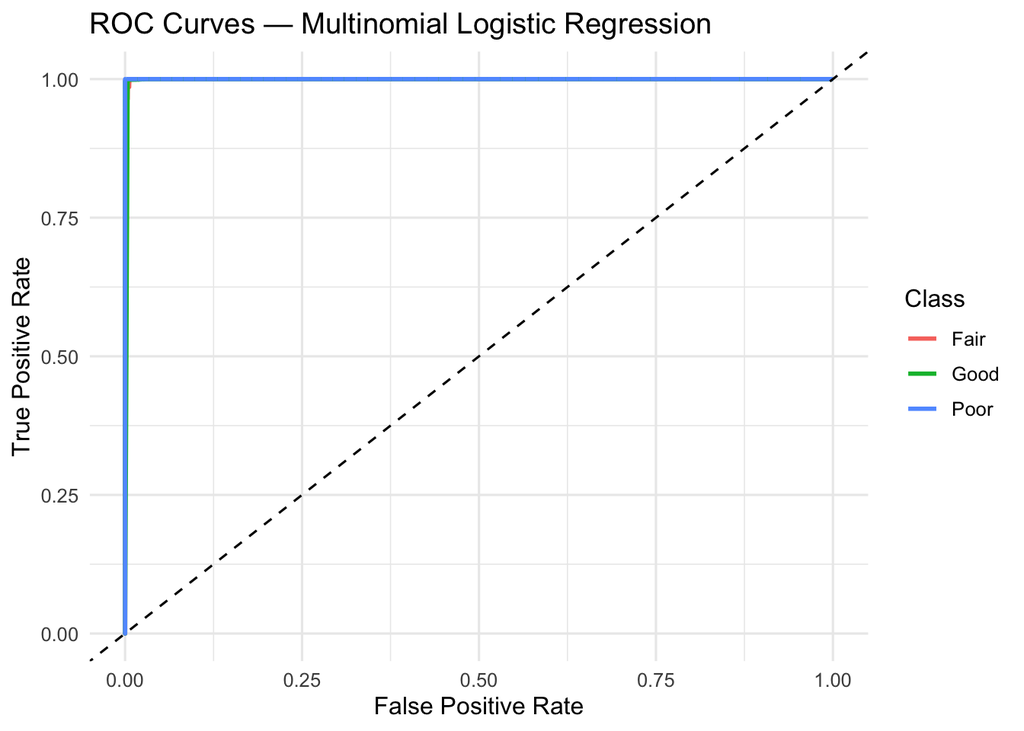

```r
# --- 4) ROC plot (all classes)
roc_long <- do.call(rbind, roc_list)
p_roc <- ggplot(roc_long, aes(x = FPR, y = TPR, color = Class)) +
  geom_line(size = 1) +
  geom_abline(slope = 1, intercept = 0, linetype = "dashed") +
  labs(title = "ROC Curves — Multinomial Logistic Regression",
       x = "False Positive Rate", y = "True Positive Rate") +
  theme_minimal(base_size = 12)
print(p_roc)
```

**CLICK TO EXPAND CODE**

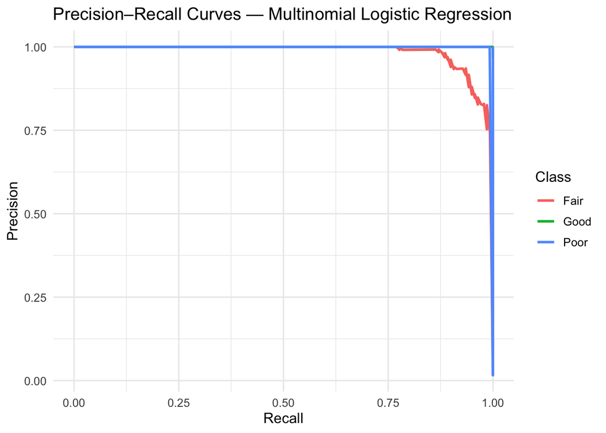

```r
# --- 5) PR plot (all classes)
pr_long <- do.call(rbind, pr_list)
p_pr <- ggplot(pr_long, aes(x = Recall, y = Precision, color = Class)) +
  geom_line(size = 1) +
  labs(title = "Precision–Recall Curves — Multinomial Logistic Regression",
       x = "Recall", y = "Precision") +
  theme_minimal(base_size = 12)
print(p_pr)
```

**ROC-AUC**: Near-perfect separability for all classes (Good 0.99997, Fair 0.99971, Poor 1.000), with minimal false positives; slight variation due to class imbalance. **PR-AUC**: Excellent overall (Good 0.99999, Fair 0.9852, Poor 1.000); Fair shows minor precision drop at high recall.  
**Overall interpretation**: The model achieves outstanding discrimination and balanced precision–recall; Fair’s slight precision loss reflects mild feature overlap. Temporal/spatial validation is recommended.

## 6.2 Linear Discriminant Analysis (LDA)

**CLICK TO EXPAND CODE**

```r
pred_class <- predict(lda_model, newdata = test_data)
pred_prob  <- predict(lda_model, newdata = test_data, type = "prob")

cm <- confusionMatrix(pred_class, test_data$class)
print(cm)
```

```
## Confusion Matrix and Statistics
##
##           Reference
## Prediction Good Fair Poor
##       Good 7007    0    0
##       Fair  762  118    3
##       Poor    0   21  126
##
## Overall Statistics
##
##                Accuracy : 0.9022
##                  95% CI : (0.8955, 0.9086)
##     No Information Rate : 0.9667
##     P-Value [Acc > NIR] : 1
##
##                   Kappa : 0.3692
##
##  Mcnemar's Test P-Value : NA
##
## Statistics by Class:
##
##                      Class: Good Class: Fair Class: Poor
## Sensitivity               0.9019     0.84892     0.97674
## Specificity               1.0000     0.90314     0.99734
## Pos Pred Value            1.0000     0.13364     0.85714
## Neg Pred Value            0.2602     0.99706     0.99962
## Prevalence                0.9667     0.01730     0.01605
## Detection Rate            0.8718     0.01468     0.01568
## Detection Prevalence      0.8718     0.10987     0.01829
## Balanced Accuracy         0.9510     0.87603     0.98704
```

```r
acc      <- unname(cm$overall["Accuracy"])
acc_low  <- unname(cm$overall["AccuracyLower"])
acc_up   <- unname(cm$overall["AccuracyUpper"])
kappa    <- unname(cm$overall["Kappa"])

list(
  Accuracy = acc,
  Accuracy_95CI = c(acc_low, acc_up),
  Kappa = kappa
)
```

```
## $Accuracy
## [1] 0.9022023
##
## $Accuracy_95CI
## [1] 0.8954994 0.9086119
##
## $Kappa
## [1] 0.369193
```

```r
byc <- as.data.frame(cm$byClass)

byc_out <- byc[, c("Sensitivity","Pos Pred Value","Balanced Accuracy")]
names(byc_out) <- c("Recall","Precision","Balanced_Accuracy")
byc_out
```

```
##                Recall Precision Balanced_Accuracy
## Class: Good 0.9019179 1.0000000         0.9509589
## Class: Fair 0.8489209 0.1336353         0.8760304
## Class: Poor 0.9767442 0.8571429         0.9870443
```

**Overall Statistics**：Accuracy = 0.9022 (95% CI: 0.8955–0.9086), Kappa = 0.3692; performance limited by class imbalance (NIR = 0.9667).  
**Statistics by Class**： • Good: Recall 0.902, Precision 1.000, Balanced Accuracy 0.951 → excellent detection. • Fair: Recall 0.849, Precision 0.134, Balanced Accuracy 0.876 → high recall but poor precision. • Poor: Recall 0.977, Precision 0.857, Balanced Accuracy 0.987 → strong detection.  
**Summary**： Performs well for Good and Poor; Fair suffers from low precision due to imbalance.

**CLICK TO EXPAND CODE**

```r
rec <- byc[,"Sensitivity"]
pre <- byc[,"Pos Pred Value"]
f1_per_class <- 2 * pre * rec / (pre + rec)
macro_f1 <- mean(f1_per_class, na.rm = TRUE)

list(
  F1_per_class = f1_per_class,
  Macro_F1 = macro_f1
)
```

```
## $F1_per_class
## [1] 0.9484299 0.2309198 0.9130435
##
## $Macro_F1
## [1] 0.6974644
```

**Macro-F1 = 0.6975** : reduced mainly by the weak performance on the minority “Fair” class. • Good: 0.948 – near-perfect • Fair: 0.231 – low precision, many false positives • Poor: 0.913 – strong balance

**CLICK TO EXPAND CODE**

```r
classes <- levels(test_data$class)

# ROC-AUC
roc_auc <- sapply(classes, function(cls) {
  y_bin <- as.numeric(test_data$class == cls)
  roc_obj <- pROC::roc(response = y_bin, predictor = pred_prob[[cls]], quiet = TRUE)
  as.numeric(pROC::auc(roc_obj))
})

# PR-AUC
pr_auc <- sapply(classes, function(cls) {
  pos <- pred_prob[[cls]][test_data$class == cls]
  neg <- pred_prob[[cls]][test_data$class != cls]
  pr  <- PRROC::pr.curve(scores.class0 = pos, scores.class1 = neg, curve = FALSE)
  unname(pr$auc.integral)
})

auc_tbl <- data.frame(
  Class   = classes,
  ROC_AUC = as.numeric(roc_auc),
  PR_AUC  = as.numeric(pr_auc)
) %>%
  mutate(
    ROC_AUC = round(ROC_AUC, 7),
    PR_AUC  = round(PR_AUC, 7)
  )

print(auc_tbl, row.names = FALSE)
```

```
##  Class   ROC_AUC    PR_AUC
##   Good 0.9999049 0.9999967
##   Fair 0.9171423 0.0884055
##   Poor 0.9996089 0.9744193
```

**CLICK TO EXPAND CODE**

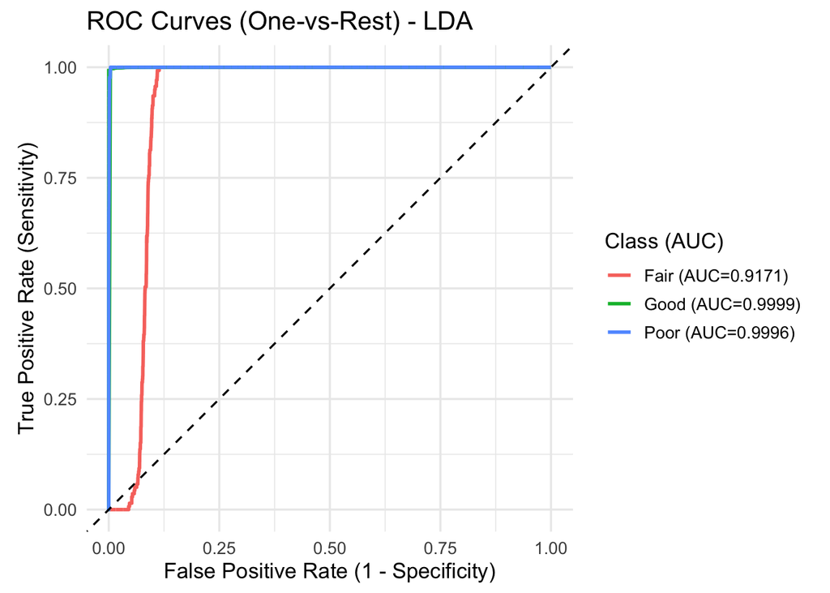

```r
# Extract ROC curve coordinates (FPR, TPR) for each category
roc_df <- do.call(rbind, lapply(classes, function(cls){
  y_bin  <- as.numeric(test_data$class == cls)
  rocobj <- pROC::roc(response = y_bin, predictor = pred_prob[[cls]], quiet = TRUE)
  aucv   <- as.numeric(pROC::auc(rocobj))
  crd    <- as.data.frame(pROC::coords(rocobj, x = "all",
                                       ret = c("specificity","sensitivity"),
                                       transpose = FALSE))
  data.frame(
    Class = cls,
    FPR   = 1 - crd$specificity,
    TPR   = crd$sensitivity,
    ROC_AUC = aucv
  )
}))

# Merge on the auc_tbl
roc_df <- roc_df %>%
  left_join(auc_tbl[, c("Class","ROC_AUC")], by = "Class", suffix = c("", ".calc")) %>%
  mutate(ROC_AUC = coalesce(ROC_AUC.calc, ROC_AUC),
         ClassLab = paste0(Class, " (AUC=", sprintf("%.4f", ROC_AUC), ")"))

# plot ROC
p_roc <- ggplot(roc_df, aes(x = FPR, y = TPR, color = ClassLab)) +
  geom_line(linewidth = 1) +
  geom_abline(slope = 1, intercept = 0, linetype = "dashed") +
  coord_equal() +
  labs(title = "ROC Curves (One-vs-Rest) - LDA",
       x = "False Positive Rate (1 - Specificity)",
       y = "True Positive Rate (Sensitivity)",
       color = "Class (AUC)") +
  theme_minimal(base_size = 13)
print(p_roc)
```

**CLICK TO EXPAND CODE**

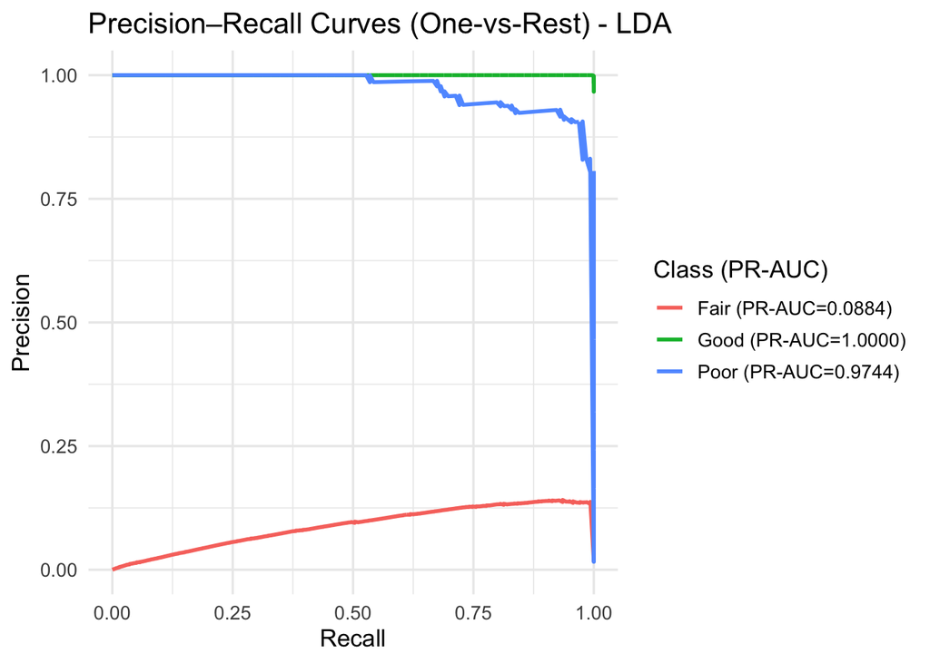

```r
pr_df <- do.call(rbind, lapply(classes, function(cls){
  pos <- pred_prob[[cls]][test_data$class == cls]
  neg <- pred_prob[[cls]][test_data$class != cls]
  pr  <- PRROC::pr.curve(scores.class0 = pos, scores.class1 = neg, curve = TRUE)
  data.frame(
    Class = cls,
    Recall    = pr$curve[,1],
    Precision = pr$curve[,2],
    PR_AUC    = unname(pr$auc.integral)
  )
}))

# Merge on PR-AUC
pr_df <- pr_df %>%
  left_join(auc_tbl[, c("Class","PR_AUC")], by = "Class", suffix = c("", ".calc")) %>%
  mutate(PR_AUC = coalesce(PR_AUC.calc, PR_AUC),
         ClassLab = paste0(Class, " (PR-AUC=", sprintf("%.4f", PR_AUC), ")"))

# plot PR
p_pr <- ggplot(pr_df, aes(x = Recall, y = Precision, color = ClassLab)) +
  geom_line(linewidth = 1) +
  labs(title = "Precision–Recall Curves (One-vs-Rest) - LDA",
       x = "Recall", y = "Precision",
       color = "Class (PR-AUC)") +
  theme_minimal(base_size = 13)
print(p_pr)
```

**ROC-AUC**： Good 0.9999, Fair 0.9171, Poor 0.9996 – excellent separation for Good and Poor; Fair weaker. **PR-AUC**： Good 0.999997, Fair 0.0884, Poor 0.9744 – high precision/recall for Good and Poor; Fair suffers from many false positives.  
**Overall**： Model excels on Good and Poor but struggles with Fair due to class imbalance.